# **Download, clean and prepare OpenDataNI data set using Google Colabs**

### Introduction

#### Why prescription data?

1. The amount of data, both a challenge and most likely to turn up something useful
2. Possibility for me to display SQL skills
3. Government spending is interesting to me because that's the sector I work in and I also have previous finance experience

#### What did I want to visualise?

Recent media coverage suggesting increased depression during Covid-19 pandemic.

**Does NI prescription data suggest an increase in depression during Covid-19 pandemic?**

### Initial investigation of data

#### Import additional python functionality

```python
from requests import get
from bs4 import BeautifulSoup
from pandas import DataFrame, read_csv, merge, concat
import plotly.express as px
import matplotlib.pyplot as plt
import json
```

#### Sample of prescriptions data (February 2021) and backup to my G-drive

```python
url = 'https://www.opendatani.gov.uk/dataset/a7b76920-bc0a-48fd-9abf-dc5ad0999886/resource/1a685b05-87e9-4fbf-856d-f9dda481567c/download/gp-prescribing---11.-february-2021.csv'
feb21_prescriptions = read_csv(url, encoding= 'unicode_escape')
feb21_prescriptions
bnf4_backup = '/content/drive/MyDrive/GIS/BNF_4_Perscriptions_Oct18_Feb21.csv'
central_nervous = read_csv(bnf4_backup)
```

#### Create a lookup for bnf codes

```python
bnf_url = 'https://openprescribing.net/bnf/'
request = get(bnf_url)
soup = BeautifulSoup(request.text)
bnf_desc = soup.find_all('a')
bnf_codes = [link.text.split(': ') for link in bnf_desc if len(link.text) > 0 and link.text[0].isnumeric()]
df = DataFrame(bnf_codes, columns=['bnf_chapter_code', 'description'])
# df.rename(columns={'0':'bnf_chapter_code', '1': 'description'}, inplace=True)
df.set_index('bnf_chapter_code', inplace=True)
```

```python
df[df.index.str.startswith('4.') & (df.index.str.len() < 5)]
#len(df.index)
```

| bnf_chapter_code | description |
| --- | --- |
| 4.1 | Hypnotics and anxiolytics |
| 4.2 | Drugs used in psychoses and related disorders |
| 4.3 | Antidepressant drugs |
| 4.4 | CNS stimulants and drugs used for ADHD |
| 4.5 | Drugs used in the treatment of obesity |
| 4.6 | Drugs used in nausea and vertigo |
| 4.7 | Analgesics |
| 4.8 | Antiepileptic drugs |
| 4.9 | Drugs used in parkinsonism and related disorders |
| 4.10 | Drugs used in substance dependence |
| 4.11 | Drugs for dementia |

```python
#df.to_csv('bnf_codes.csv')
dots = df[df.index.str.contains('\.+')==False]
dots.index
```

```
Index(['1', '2', '3', '4', '5', '6', '7', '8', '9', '10', '11', '12', '13',
       '14', '15', '18', '19', '20', '21', '22', '23'],
      dtype='object', name='bnf_chapter_code')
```

```python
dots.reset_index(inplace=True)
feb21_bnf_desc = merge(feb21_prescriptions, dots['description'], left_on='BNF Chapter', right_on=dots['bnf_chapter_code'].astype(int))
feb21_bnf_desc.to_csv('feb21_bnf_desc.csv')
```

```python
print(feb21_prescriptions.columns)
#feb21_prescriptions[feb21_prescriptions['BNF Sub-Paragraph'] != 0][['BNF Code', 'BNF Chapter', 'BNF Section', 'BNF Paragraph','BNF Sub-Paragraph']]
columns_keep = ['Practice', 'Year', 'Month', 'VTM_NM', 'Actual Cost (£)', 'BNF Chapter', 'BNF Section']
columns_drop = [cols  for cols in feb21_prescriptions.columns if cols not in columns_keep]
feb21_prescriptions = feb21_prescriptions.drop(columns=columns_drop)
feb21_prescriptions
```

[output not shown]

### Diverged into gathering general info on OpenDataNI

#### Looked at open data API

```python
datasets = json.loads(get('https://www.opendatani.gov.uk/api/3/action/package_list').text)
```

```python
datasets['result'][0]
```

```
'2011-census-microdata-sample-of-anonymised-records-teaching-file'
```

```python
opendatani = []
datasets['result'] ## 698 datasets
url_base = 'https://www.opendatani.gov.uk/api/3/action/package_show?id='
for dataset_id in datasets['result']:
  url = url_base + dataset_id
  package_content = json.loads(get(url).text)
  #primary_group = package_content['result']['groups'][0]['display_name']
  if 'num_resources' in package_content['result'] and not package_content['result']['private']:
    number_items =  package_content['result']['num_resources']
    opendatani.append([dataset_id,number_items])
len(opendatani)
```

```
670
```

#### Largest datasets by number of files, then estimate total number of rows

698 Datasets held in OpenDataNI, 670 of which are public and have content

1. House Price lgd level has 99 csvs of ~15 rows = ~1500 rows
2. House Price electoral ward has 99 csv of ~600 rows = ~60K rows
3. GP Prescribing has 95 csv of ~450K rows = ~45M rows
4. 2014 Council Elections 84 css of ~ 50 rows = ~5000 rows
5. [Drainage assets](https://www.opendatani.gov.uk/dataset/drainage-asset) > too messy to estimate
6. NI Direct Website 50 csv of ~50k rows = 2.5M rows

**2nd biggest open data N.I. source is ~ 20x smaller!**

```python
opendatani.sort(key = lambda x: x[1], reverse=True)
opendatani[:10]
```

```
[['northern-ireland-annual-descriptive-house-price-statistics-electoral-ward-level',
  99],
 ['northern-ireland-annual-descriptive-house-price-statistics-lgd-level', 99],
 ['gp-prescribing-data', 95],
 ['northern-ireland-local-councils-election-22-may-2014', 84],
 ['drainage-asset', 57],
 ['ni-direct-website-data', 56],
 ['opendatani-dataset-numbers-by-publisher', 54],
 ['further-education-activity', 45],
 ['notification-of-infectious-diseases', 45],
 ['ni-water-customer-tap-authorised-supply-point-results', 40]]
```

#### Check time delay for 'prescribing-data' updates

```python
prescription_homepage = 'https://www.opendatani.gov.uk/api/3/action/package_show?id=gp-prescribing-data'
```

```python
prescription_content = json.loads(get(prescription_homepage).text)
created = []
for r in prescription_content['result']['resources']:
  created.append([r['name'], r['created']])
created[:10]
```

```
[['GP Prescribing Northern Ireland, February 2021',
  '2021-04-02T09:57:53.780631'],
 ['GP Prescribing Northern Ireland, January 2021',
  '2021-03-08T13:50:34.170726'],
 ['GP Prescribing Northern Ireland, December 2020 ',
  '2021-02-01T18:06:28.315233'],
 ['GP Prescribing Northern Ireland, November 2020 ',
  '2021-01-07T13:56:58.163299'],
 ['GP Prescribing Northern Ireland, October 2020',
  '2020-12-02T14:34:29.394028'],
 ['GP Prescribing Northern Ireland, September 2020',
  '2020-11-02T17:36:04.293676'],
 ['GP Prescribing Northern Ireland, August 2020',
  '2020-10-02T11:07:11.068837'],
 ['GP Prescribing Northern Ireland, July 2020', '2020-09-02T09:59:11.255830'],
 ['GP Prescribing Northern Ireland, June 2020', '2020-07-29T14:01:14.453315'],
 ['GP Prescribing Northern Ireland, May 2020', '2020-07-01T14:02:18.245770']]
```

Appears the target is the 2nd of month after the following month, i.e. March 2021 should be published on 2nd May

```python
bnf_chapter_cost = feb21_bnf_desc.groupby('description')['Actual Cost (£)'].sum().sort_values(ascending=False)
```

```
<BarContainer object of 20 artists>
```

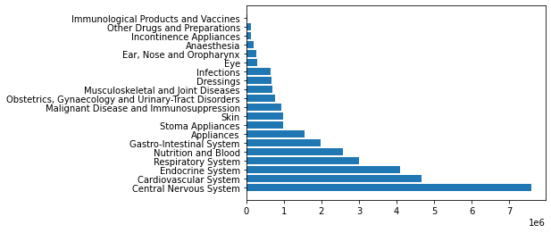

```python
bnf_chapter_cost
plt.barh(bnf_chapter_cost.index, bnf_chapter_cost)
percent = bnf
plt.text
```

### Main extract of data to CSV

#### Get a list of csv files from prescription home page

```python
opendata_prescriptions_url = 'https://www.opendatani.gov.uk/dataset/gp-prescribing-data'
request = get(opendata_prescriptions_url)
soup = BeautifulSoup(request.text)
```

```python
resources_details = soup.find_all('a', {'class': 'heading'})
resources_url  = soup.find_all('a', {'class': 'resource-url-analytics'})
csv_list = []
for i in range(len(resources_url)):
  csv_list.append([resources_details[i]['title'], resources_url[i]['href']])  ##April 2013 - Feb 2021 = 95 csv's
 ## Apr 13 - Oct 17 - hscni. Nov 17 - present = opendatani
```

[output not shown]

#### Get the content of exch csv and meadge into single pandas data frame

```python
df_list = []
for item in csv_list[:29]:
  df_list.append(read_csv(item[1], encoding= 'unicode_escape'))
  print(f'Scraped {item[0]}')  ## 144 sec
df = concat(df_list) ## 3 sec
```

[output not shown]

#### Create some quick summaries

```python
df  ##[13266675 rows x 17 columns]
df.groupby(['Year', 'Month'])['Actual Cost (£)'].sum().apply(lambda x: "£{:.1f}M".format((x/1000000)))
central_nervous = df[df['BNF Chapter'] == 4] ## --2700207 rows × 17 columns
df.groupby(['Year'])['Actual Cost (£)'].agg(['sum', 'count']) ## ~ £400M / year 5.5M prescriptions, 5% inc 2020 > 2021
```

| Year | sum | count |
| --- | --- | --- |
| 2018 | 9.411445e+07 | 1398391 |
| 2019 | 3.916037e+08 | 5548474 |
| 2020 | 4.146820e+08 | 5433540 |
| 2021 | 6.695431e+07 | 886270 |

```python
central_nervous.groupby(['Year', 'Month'])['Actual Cost (£)'].sum().apply(lambda x: "£{:.1f}M".format((x/1000000)))
central_nervous.groupby(['Year', 'BNF Section'])['Actual Cost (£)'].sum().apply(lambda x: "£{:.1f}K".format((x/1000)))
central_nervous.groupby(['BNF Section'])['Actual Cost (£)'].sum().apply(lambda x: "£{:.1f}M".format((x/1000000)))
```

```
BNF Section
1     £14.1M
2     £28.2M
3     £28.9M
4      £8.0M
5      £0.6M
6      £5.8M
7     £56.6M
8     £41.2M
9      £8.5M
10     £4.2M
11     £4.3M
Name: Actual Cost (£), dtype: object
```

#### **2nd** appempt at Tableau, replicate the above summary

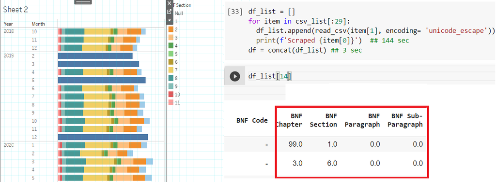

#### Fix 4 months that are not showing DNF Sections (Mis-matched data types)

```python
bnf4_backup = '/content/drive/MyDrive/GIS/BNF_4_Perscriptions_Oct18_Feb21.csv'
#df.to_csv('Prescriptions_Oct2018-Feb2021.csv') ## 114 sec, download look longer to generate ~ 2GB
central_nervous.to_csv(bnf4_backup) ## 26sec to save csv to Gdrive, 160 sec to download 380MB
#central_nervous = read_csv(bnf4_backup)  ##9 sec to read 340MB ~ 300Mb / sec!!
#central_nervous[['BNF Chapter',	'BNF Section',	'BNF Paragraph']] = central_nervous[['BNF Chapter',	'BNF Section',	'BNF Paragraph']].astype(int)
```

#### Fix missing data from Jan 2019

```python
jan2019 = read_csv(csv_list[25][1], encoding= 'unicode_escape')
jan2019['BNF Chapter'] = jan2019['BNF Chapter'].str.replace('-', '0')
jan2019['BNF Section'] = jan2019['BNF Section'].str.replace('-', '0')
jan2019['BNF Paragraph'] = jan2019['BNF Paragraph'].str.replace('-', '0')
jan2019[['BNF Chapter',	'BNF Section',	'BNF Paragraph']] = jan2019[['BNF Chapter',	'BNF Section',	'BNF Paragraph']].astype(float).astype(int)
jan2019_bnf4 = jan2019[jan2019['BNF Chapter'] == 4]
jan2019_bnf4
frames = [central_nervous,jan2019_bnf4]
central_nervous = concat(frames)
central_nervous = central_nervous
central_nervous = central_nervous.drop(['Unnamed: 0'], axis=1)
central_nervous.reset_index(inplace=True, drop=True)
central_nervous
```